# E.Roman_HW4.rmd

Enid Roman

2023-02-19

Read Pix Set Up Initialization

```r
library(jpeg)
```

```r
library(OpenImageR)
library(EBImage)
getwd()
```

```
## [1] "C:/Users/enidr/OneDrive/Documents/CUNY SPS DATA 605/CUNY SPS DATA 605 Week 4"
```

**Use of Graphics**

We add graphics to the data set.

```r
# Prepare for Image Processing
num=17
files=list.files("./jpg/",pattern=".jpg")[1:num]
```

```r
#Setting the file path
dim(readJPEG(paste0(file.path(getwd(),'jpg//'),files[1])))
```

```
## [1] 1200 2500    3
```

```r
is.na(getwd())
```

```
## [1] FALSE
```

**View Shoes Function**

```r
# Set Adj. Parameters
height=1200; width=2500;scale=20
plot_jpeg = function(path, add=FALSE)
{ jpg = readJPEG(path, native=T) # read the file
  res = dim(jpg)[2:1] # get the resolution, [x, y]
  if (!add) # initialize an empty plot area if add==FALSE
    plot(1,1,xlim=c(1,res[1]),ylim=c(1,res[2]),asp=1,type='n',xaxs='i',yaxs='i',xaxt='n',yaxt='n',xlab='',ylab='',bty='n')
  rasterImage(jpg,1,1,res[1],res[2])
}
```

**Load the Data into an Array**

This is loading the data in the array by each file, an image structure into the array Dimensions will be number of images x ht/scale x wt/scale, channel. There are 3 channels for red, green and blue. Resize from the EBI package will scale the images to the desired dimension.

```r
# Load
im=array(rep(0,length(files)*height/scale*width/scale*3), dim=c(length(files), height/scale, width/scale,3))

for (i in 1:17){
temp=resize(readJPEG(paste0('jpg//', files[i])),height/scale, width/scale)
  im[i,,,]=array(temp,dim=c(1, height/scale, width/scale,3))}
```

**Vectorize**

```r
flat=matrix(0, 17, prod(dim(im)))
for (i in 1:17) {
  newim <- readJPEG(paste0('jpg//', files[i]))
  r=as.vector(im[i,,,1]); g=as.vector(im[i,,,2]);b=as.vector(im[i,,,3])
  flat[i,] <- t(c(r, g, b))
}
shoes=as.data.frame(t(flat))
dim(flat)
```

```
## [1]     17 382500
```

```r
dim(shoes)
```

```
## [1] 382500     17
```

```r
str(shoes)
```

```
## 'data.frame':    382500 obs. of  17 variables:
##  $ V1 : num  1 1 1 1 1 1 1 1 1 1 ...
##  $ V2 : num  1 1 1 1 1 1 1 1 1 1 ...
##  $ V3 : num  1 1 1 1 1 1 1 1 1 1 ...
##  $ V4 : num  1 1 1 1 1 1 1 1 1 1 ...
##  $ V5 : num  1 1 1 1 1 1 1 1 1 1 ...
##  $ V6 : num  1 1 1 1 1 1 1 1 1 1 ...
##  $ V7 : num  1 1 1 1 1 1 1 1 1 1 ...
##  $ V8 : num  1 1 1 1 1 1 1 1 1 1 ...
##  $ V9 : num  1 1 1 1 1 1 1 1 1 1 ...
##  $ V10: num  1 1 1 1 1 1 1 1 1 1 ...
##  $ V11: num  1 1 1 1 1 1 1 1 1 1 ...
##  $ V12: num  1 1 1 1 1 1 1 1 1 1 ...
##  $ V13: num  1 1 1 1 1 1 1 1 1 1 ...
##  $ V14: num  1 1 1 1 1 1 1 1 1 1 ...
##  $ V15: num  1 1 1 1 1 1 1 1 1 1 ...
##  $ V16: num  1 1 1 1 1 1 1 1 1 1 ...
##  $ V17: num  1 1 1 1 1 1 1 1 1 1 ...
```

**Actual Plots**

Using the plot_jpeg function to see the images

[figure not shown]

[figure not shown]

```r
#Old Shoes
par(mfrow=c(3,3))
par(mai=c(.3,.3,.3,.3))
for (i in 1:17){  #plot the first images only
plot_jpeg(writeJPEG(im[i,,,]))
}
```

**Get Eigencomponents from Correlation Structure**

We are scaling the pixels in the array. Now we need to scale and center data using the scale function. We are normalizing the data to mean=0 and sd=1.

```r
scaled=scale(shoes, center = TRUE, scale = TRUE)
mean.shoe=attr(scaled, "scaled:center") #saving for classification
std.shoe=attr(scaled, "scaled:scale")  #saving for classification...later
dim(scaled)
```

```
## [1] 382500     17
```

```r
str(scaled)
```

```
##  num [1:382500, 1:17] 0.651 0.651 0.651 0.651 0.651 ...
##  - attr(*, "dimnames")=List of 2
##   ..$ : NULL
##   ..$ : chr [1:17] "V1" "V2" "V3" "V4" ...
##  - attr(*, "scaled:center")= Named num [1:17] 0.867 0.755 0.909 0.779 0.762 ...
##   ..- attr(*, "names")= chr [1:17] "V1" "V2" "V3" "V4" ...
##  - attr(*, "scaled:scale")= Named num [1:17] 0.205 0.343 0.194 0.327 0.328 ...
##   ..- attr(*, "names")= chr [1:17] "V1" "V2" "V3" "V4" ...
```

**Calculate Covariance (Correlation)**

We are using the Correlation matrix. All the preceeding work was done to get to this matrix. It is this correlation matrix that will be used to determine the eigencomponents.

```r
Sigma_=cor(scaled)
dim(Sigma_)
```

```
## [1] 17 17
```

```r
str(Sigma_)
```

```
##  num [1:17, 1:17] 1 0.787 0.678 0.654 0.727 ...
##  - attr(*, "dimnames")=List of 2
##   ..$ : chr [1:17] "V1" "V2" "V3" "V4" ...
##   ..$ : chr [1:17] "V1" "V2" "V3" "V4" ...
```

```r
Sigma_
```

```
##            V1        V2        V3        V4        V5        V6        V7
## V1  1.0000000 0.7872851 0.6776806 0.6544080 0.7265980 0.6526121 0.6833201
## V2  0.7872851 1.0000000 0.5265192 0.8346666 0.8313697 0.4974713 0.5452394
## V3  0.6776806 0.5265192 1.0000000 0.3996754 0.4560180 0.6677417 0.6925274
## V4  0.6544080 0.8346666 0.3996754 1.0000000 0.7982592 0.4516536 0.5003529
## V5  0.7265980 0.8313697 0.4560180 0.7982592 1.0000000 0.5039991 0.5657749
## V6  0.6526121 0.4974713 0.6677417 0.4516536 0.5039991 1.0000000 0.8766556
## V7  0.6833201 0.5452394 0.6925274 0.5003529 0.5657749 0.8766556 1.0000000
## V8  0.7560167 0.8386777 0.5447951 0.8512430 0.8125317 0.6770704 0.6651375
## V9  0.5943100 0.8226958 0.3142268 0.8543069 0.7992001 0.3968194 0.4426932
## V10 0.7250559 0.8539275 0.4332609 0.7899076 0.8746777 0.4563027 0.5134776
## V11 0.6973755 0.8153650 0.4336216 0.7689457 0.8420656 0.4380275 0.4884842
## V12 0.7403649 0.7045207 0.6556382 0.6127174 0.6556111 0.6497151 0.6954737
## V13 0.6922406 0.5943306 0.6064572 0.5314402 0.5975513 0.6720664 0.6979225
## V14 0.6561369 0.6316040 0.5724038 0.5781606 0.6257459 0.5942177 0.6371818
## V15 0.7046243 0.7113572 0.5662060 0.6572434 0.6939202 0.5563215 0.5942733
## V16 0.7289012 0.6932984 0.5814029 0.6411786 0.7189399 0.6294994 0.6653560
## V17 0.7229931 0.6882444 0.5803742 0.6129113 0.6771056 0.5761203 0.6180556
##            V8        V9       V10       V11       V12       V13       V14
## V1  0.7560167 0.5943100 0.7250559 0.6973755 0.7403649 0.6922406 0.6561369
## V2  0.8386777 0.8226958 0.8539275 0.8153650 0.7045207 0.5943306 0.6316040
## V3  0.5447951 0.3142268 0.4332609 0.4336216 0.6556382 0.6064572 0.5724038
## V4  0.8512430 0.8543069 0.7899076 0.7689457 0.6127174 0.5314402 0.5781606
## V5  0.8125317 0.7992001 0.8746777 0.8420656 0.6556111 0.5975513 0.6257459
## V6  0.6770704 0.3968194 0.4563027 0.4380275 0.6497151 0.6720664 0.5942177
## V7  0.6651375 0.4426932 0.5134776 0.4884842 0.6954737 0.6979225 0.6371818
## V8  1.0000000 0.8189832 0.8034116 0.7634081 0.6949891 0.6342264 0.6425449
## V9  0.8189832 1.0000000 0.8050235 0.7639324 0.5417763 0.4402583 0.4948664
## V10 0.8034116 0.8050235 1.0000000 0.8797837 0.6871696 0.5871662 0.6344487
## V11 0.7634081 0.7639324 0.8797837 1.0000000 0.6973725 0.6136412 0.6736291
## V12 0.6949891 0.5417763 0.6871696 0.6973725 1.0000000 0.7515997 0.7983485
## V13 0.6342264 0.4402583 0.5871662 0.6136412 0.7515997 1.0000000 0.7738524
## V14 0.6425449 0.4948664 0.6344487 0.6736291 0.7983485 0.7738524 1.0000000
## V15 0.6920963 0.5965985 0.7056080 0.7348275 0.8138716 0.7377756 0.8451754
## V16 0.7053563 0.5709788 0.7078820 0.7184022 0.7792859 0.8487052 0.8218953
## V17 0.6784023 0.5544874 0.6970469 0.7274268 0.8390444 0.7541332 0.7958402
##           V15       V16       V17
## V1  0.7046243 0.7289012 0.7229931
## V2  0.7113572 0.6932984 0.6882444
## V3  0.5662060 0.5814029 0.5803742
## V4  0.6572434 0.6411786 0.6129113
## V5  0.6939202 0.7189399 0.6771056
## V6  0.5563215 0.6294994 0.5761203
## V7  0.5942733 0.6653560 0.6180556
## V8  0.6920963 0.7053563 0.6784023
## V9  0.5965985 0.5709788 0.5544874
## V10 0.7056080 0.7078820 0.6970469
## V11 0.7348275 0.7184022 0.7274268
## V12 0.8138716 0.7792859 0.8390444
## V13 0.7377756 0.8487052 0.7541332
## V14 0.8451754 0.8218953 0.7958402
## V15 1.0000000 0.8122591 0.8124942
## V16 0.8122591 1.0000000 0.8180335
## V17 0.8124942 0.8180335 1.0000000
```

**Get the Eigencomponents**

```r
myeigen=eigen(Sigma_)
myeigen
```

```
## eigen() decomposition
## $values
##  [1] 11.77794388  1.72081925  0.86806022  0.46371734  0.32298978  0.27624335
##  [7]  0.23790552  0.20503228  0.16487012  0.15399147  0.14378933  0.13577975
## [13]  0.12975748  0.11385581  0.10510016  0.10124270  0.07890155
##
## $vectors
##             [,1]        [,2]        [,3]         [,4]         [,5]         [,6]
##  [1,] -0.2515577 -0.05962807 -0.14114605  0.379564498  0.328384491  0.063548478
##  [2,] -0.2564669  0.22970932 -0.09482706  0.230635627 -0.032641499  0.118423122
##  [3,] -0.1974907 -0.34526438 -0.24576573  0.652153338 -0.171726622  0.244730346
##  [4,] -0.2391458  0.30516320 -0.13606194 -0.123183806 -0.327267101  0.337264863
##  [5,] -0.2525203  0.23895414 -0.06096558 -0.015140135  0.320237763 -0.134084234
##  [6,] -0.2096918 -0.34776361 -0.42324640 -0.330938410  0.005186903 -0.204506297
##  [7,] -0.2220439 -0.32176935 -0.36923615 -0.258761028  0.032948289 -0.251123643
```

[output cut: 64 more lines]

```r
cumsum(myeigen$values) / sum(myeigen$values)
```

```
##  [1] 0.6928202 0.7940449 0.8451073 0.8723847 0.8913841 0.9076338 0.9216282
##  [8] 0.9336889 0.9433872 0.9524455 0.9609037 0.9688907 0.9765235 0.9832209
## [15] 0.9894033 0.9953587 1.0000000
```

**Eigenshoes**

The new shoes are a reduced number that are built by the new linear combinations. The new shoes are eigenvectors.

80% is between 2 and 3 components….. Here is 2

```r
scaling=diag(myeigen$values[1:2]^(-1/2)) / (sqrt(nrow(scaled)-1))

scaling
```

```
##              [,1]        [,2]
## [1,] 0.0004711401 0.000000000
## [2,] 0.0000000000 0.001232586
```

```r
eigenshoes=scaled%*%myeigen$vectors[,1:2]%*%scaling
dim(eigenshoes)
```

```
## [1] 382500      2
```

```r
str(eigenshoes)
```

```
##  num [1:382500, 1:2] -0.0012 -0.0012 -0.0012 -0.0012 -0.0012 ...
```

Image 1

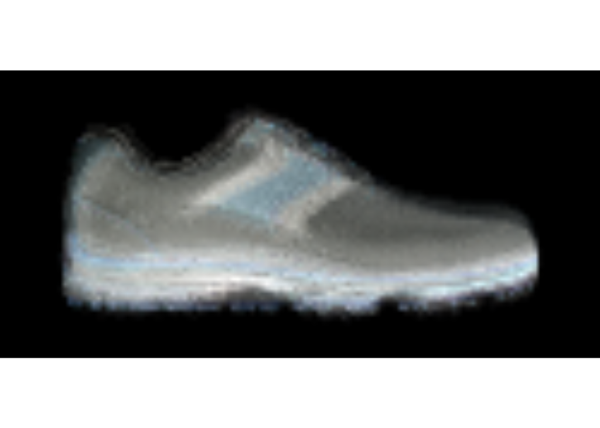

```r
scaling=diag(myeigen$values[1:5]^(-1/2)) / (sqrt(nrow(scaled)-1))
eigenshoes=scaled%*%myeigen$vectors[,1:5]%*%scaling
par(mfrow=c(2,3))
imageShow(array(eigenshoes[,1], c(60,125,3)))
```

Image 2

[figure not shown]

```r
imageShow(array(eigenshoes[,2], c(60,125,3)))
```

**Generate Principal Components** Transform the images

```r
#Generate Variables
height=1200
width=2500
scale=20
newdata=im
dim(newdata)=c(length(files),height*width*3/scale^2)
mypca=princomp(t(as.matrix(newdata)), scores=TRUE, cor=TRUE)
################################################################
```

**Eigenshoes** Generate Eigenshoes

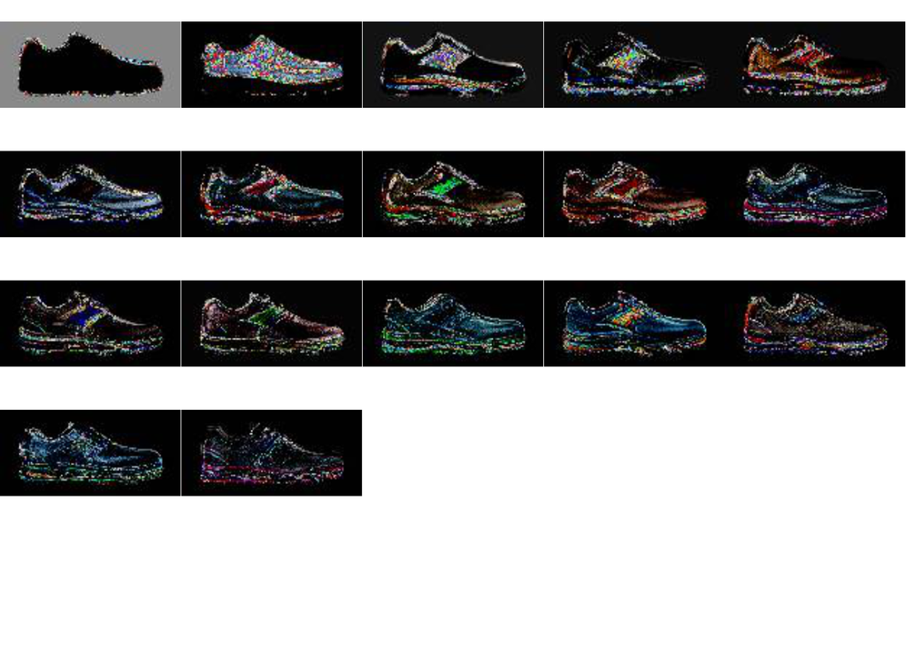

```r
#Eigenshoes
mypca2=t(mypca$scores)
dim(mypca2)=c(length(files),height/scale,width/scale,3)
par(mfrow=c(5,5))
par(mai=c(.001,.001,.001,.001))
for (i in 1:17){#plot the first 25 Eigenshoes only
plot_jpeg(writeJPEG(mypca2[i,,,], bg="white"))  #complete without reduction
}
```

```r
a=round(mypca$sdev[1:17]^2/ sum(mypca$sdev^2),3)
cumsum(a)
```

```
##  Comp.1  Comp.2  Comp.3  Comp.4  Comp.5  Comp.6  Comp.7  Comp.8  Comp.9 Comp.10
##   0.693   0.794   0.845   0.872   0.891   0.907   0.921   0.933   0.943   0.952
## Comp.11 Comp.12 Comp.13 Comp.14 Comp.15 Comp.16 Comp.17
##   0.960   0.968   0.976   0.983   0.989   0.995   1.000
```

**New Data Set**

```r
x = t(t(eigenshoes)%*%scaled)
```

**REFERENCES** Fulton, Larry. Eigenshoes. https://rpubs.com/R-Minator/eigenshoes.